# Data Science for Business - Week 08: Kaggle Competition on Prediction of Elecricity Consumption

Oliver Mueller

# Initialize notebook

Load required packages.

```r
library(tidyverse)
library(lubridate)
library(ggthemr)
library(tidymodels)
```

Set up workspace, i.e., remove all existing data from working memory, initialize the random number generator, turn of scientific notation of large numbers, set a standard theme for plotting. Finally, we activate parallel processing on multiple CPU cores.

```r
knitr::opts_chunk$set(echo = TRUE, warning = FALSE)
rm(list=ls())
set.seed(42)
options(scipen=10000)
ggthemr('fresh')
doParallel::registerDoParallel()
```

# Problem description

In this Kaggle competition, you will develop accurate models of metered building electricity usage in the following areas. The data comes from 100 buildings over a one-year time period.

# Load data

Load data from CSV files.

```r
train <- read_csv("train.csv")
test <- read_csv("test.csv")
```

# Explore data

Summary stats.

```r
summary(train)
```

```
  building_id       timestamp                   meter_reading     primary_use         square_feet
 Min.   :  0.00   Min.   :2016-01-01 00:00:00   Min.   :   0.00   Length:698675      Min.   :   283
 1st Qu.: 24.00   1st Qu.:2016-04-02 00:00:00   1st Qu.:   0.00   Class :character   1st Qu.: 24456
 Median : 50.00   Median :2016-07-02 18:00:00   Median :  71.26   Mode  :character   Median : 53130
 Mean   : 50.06   Mean   :2016-07-02 11:21:49   Mean   : 231.25                      Mean   : 88803
 3rd Qu.: 76.00   3rd Qu.:2016-10-02 04:00:00   3rd Qu.: 302.71                      3rd Qu.:103286
 Max.   :100.00   Max.   :2016-12-31 23:00:00   Max.   :4521.00                      Max.   :487433

   year_built   air_temperature cloud_coverage   dew_temperature precip_depth_1_hr sea_level_pressure
 Min.   :1968   Min.   : 1.70   Min.   :0.00     Min.   :-9.40   Min.   : -1.00    Min.   : 992
 1st Qu.:1985   1st Qu.:18.90   1st Qu.:2.00     1st Qu.:13.30   1st Qu.:  0.00    1st Qu.:1016
 Median :2001   Median :23.90   Median :2.00     Median :18.30   Median :  0.00    Median :1018
 Mean   :1996   Mean   :22.84   Mean   :3.04     Mean   :16.82   Mean   :  1.37    Mean   :1018
 3rd Qu.:2007   3rd Qu.:26.70   3rd Qu.:4.00     3rd Qu.:22.20   3rd Qu.:  0.00    3rd Qu.:1021
 Max.   :2016   Max.   :36.10   Max.   :9.00     Max.   :25.60   Max.   :343.00    Max.   :1030
                NA's   :223     NA's   :304516   NA's   :223     NA's   :84        NA's   :6722
 wind_direction    wind_speed
 Min.   :  0.0   Min.   : 0.000
 1st Qu.: 60.0   1st Qu.: 2.100
 Median :140.0   Median : 3.100
 Mean   :156.4   Mean   : 3.377
 3rd Qu.:260.0   3rd Qu.: 4.600
 Max.   :360.0   Max.   :15.400
 NA's   :19922
```

Histogram of `meter_reading`.

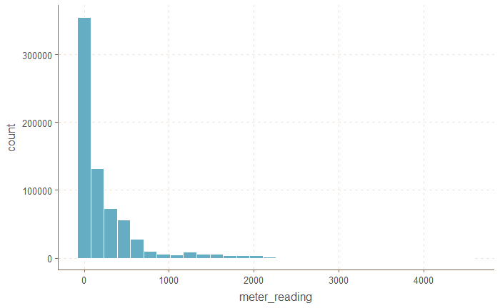

```r
ggplot(data=filter(train)) +
  geom_histogram(mapping = aes(x=meter_reading), color="white")
```

Explore numerical predictors.

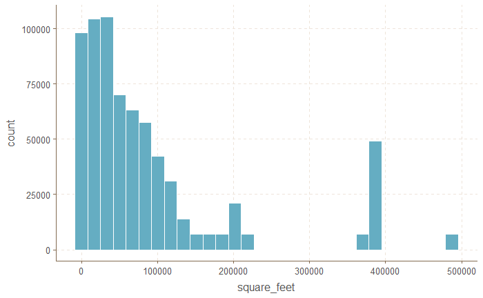

```r
ggplot(data=train) +
  geom_histogram(mapping = aes(x=square_feet), color="white")
```

Explore categorical predictors.

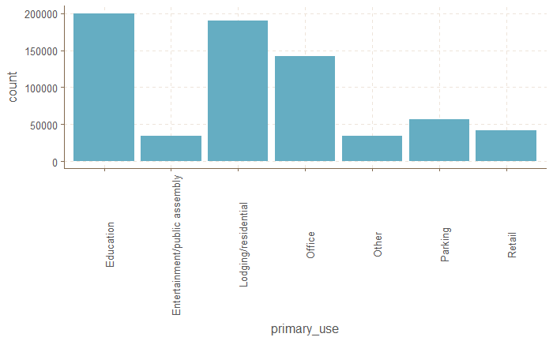

```r
ggplot(data=train) +
  geom_bar(mapping = aes(x=primary_use)) +
  theme(axis.text.x = element_text(angle = 90))
```

Explore bivariate relationships between target and categorical predictors.

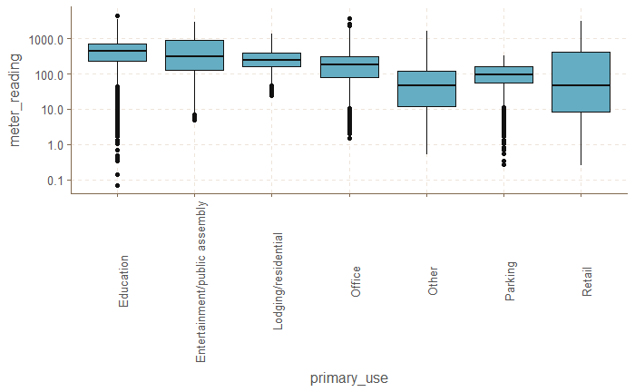

```r
ggplot(data=train) +
  geom_boxplot(mapping = aes(y=meter_reading, x=primary_use)) +
  scale_y_log10() +
  theme(axis.text.x = element_text(angle = 90))
```

Explore bivariate relationships between target and numerical predictors.

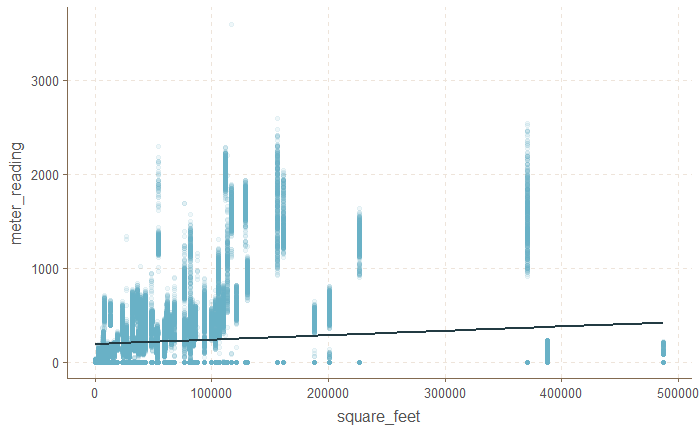

```r
ggplot(data=sample_frac(train, 0.1)) +
  geom_point(mapping=aes(x=square_feet, y=meter_reading), alpha=0.1) +
  geom_smooth(mapping=aes(x=square_feet, y=meter_reading), method="lm")
```

# Modeling

## Model

Create a simple `model` specification for an OLS linear regression.

```r
electricity_mod_01 <- linear_reg() %>%
  set_engine("lm")

electricity_mod_01
```

```
Linear Regression Model Specification (regression)

Computational engine: lm
```

## Recipe

Next, we specify a `recipe` for data preprocessing.

```r
electricity_recipe <-
  recipe(meter_reading ~ ., data = train) %>%
  step_mutate(
    month = as.factor(lubridate::month(timestamp)),
    dow = as.factor(lubridate::wday(timestamp)),
    dom = as.factor(lubridate::day(timestamp))
  ) %>%
  step_rm(timestamp, building_id) %>%
  step_medianimpute(all_numeric()) %>%
  step_modeimpute(all_nominal()) %>%
  step_normalize(all_numeric(), -all_outcomes()) %>%
  step_dummy(all_nominal(), -all_outcomes())

electricity_recipe
```

```
Recipe

Inputs:
```

| role | #variables |
| --- | --- |
| outcome | 1 |
| predictor | 12 |

```
Operations:

Variable mutation
Delete terms timestamp, building_id
Median Imputation for all_numeric()
Mode Imputation for all_nominal()
Centering and scaling for all_numeric(), -all_outcomes()
Dummy variables from all_nominal(), -all_outcomes()
```

`Bake` the recipe, just the check whether it produces the expected results.

```r
tmp <- electricity_recipe %>%
  prep() %>%
  bake(train)

head(tmp)
```

| square_feet | year_built | air_temperature | cloud_coverage | dew_temperature | precip_depth_1_hr | sea_level_pressure | wind_direction | wind_speed | meter_reading | primary_use_Entertainment.public.assembly | primary_use_Lodging.residential | primary_use_Office | primary_use_Other | primary_use_Parking | primary_use_Retail | month_X2 | month_X3 | month_X4 | month_X5 | month_X6 | month_X7 | month_X8 | month_X9 | month_X10 | month_X11 | month_X12 | dow_X2 | dow_X3 | dow_X4 | … |
| --- | --- | --- | --- | --- | --- | --- | --- | --- | --- | --- | --- | --- | --- | --- | --- | --- | --- | --- | --- | --- | --- | --- | --- | --- | --- | --- | --- | --- | --- | --- |
| -0.7865729 | 0.5814284 | 0.3579057 | 2.037686 | 0.4875366 | -0.1064462 | 0.4268177 | -1.33649 | -1.566133 | 0 | 0 | 0 | 0 | 0 | 0 | 0 | 0 | 0 | 0 | 0 | 0 | 0 | 0 | 0 | 0 | 0 | 0 | 0 | 0 | 0 | … |
| -0.7623041 | -0.3223918 | 0.3579057 | 2.037686 | 0.4875366 | -0.1064462 | 0.4268177 | -1.33649 | -1.566133 | 0 | 0 | 0 | 0 | 0 | 0 | 0 | 0 | 0 | 0 | 0 | 0 | 0 | 0 | 0 | 0 | 0 | 0 | 0 | 0 | 0 | … |
| -0.5950083 | 0.4423791 | 0.3579057 | 2.037686 | 0.4875366 | -0.1064462 | 0.4268177 | -1.33649 | -1.566133 | 0 | 0 | 0 | 0 | 0 | 0 | 0 | 0 | 0 | 0 | 0 | 0 | 0 | 0 | 0 | 0 | 0 | 0 | 0 | 0 | 0 | … |
| 0.2540531 | -1.4347858 | 0.3579057 | 2.037686 | 0.4875366 | -0.1064462 | 0.4268177 | -1.33649 | -1.566133 | 0 | 0 | 0 | 0 | 0 | 0 | 0 | 0 | 0 | 0 | 0 | 0 | 0 | 0 | 0 | 0 | 0 | 0 | 0 | 0 | 0 | … |
| -0.7383277 | 0.3033299 | 0.3579057 | 2.037686 | 0.4875366 | -0.1064462 | 0.4268177 | -1.33649 | -1.566133 | 0 | 0 | 0 | 0 | 0 | 0 | 0 | 0 | 0 | 0 | 0 | 0 | 0 | 0 | 0 | 0 | 0 | 0 | 0 | 0 | 0 | … |
| -0.5647179 | 0.9985762 | 0.3579057 | 2.037686 | 0.4875366 | -0.1064462 | 0.4268177 | -1.33649 | -1.566133 | 0 | 0 | 0 | 1 | 0 | 0 | 0 | 0 | 0 | 0 | 0 | 0 | 0 | 0 | 0 | 0 | 0 | 0 | 0 | 0 | 0 | … |

## Workflow

The final specification is for the `workflow`, which glues together the `model` and `recipe`.

```r
electricity_wflow <- workflow() %>%
  add_model(electricity_mod_01) %>%
  add_recipe(electricity_recipe)

electricity_wflow
```

```
== Workflow ====================================================================================================
Preprocessor: Recipe
Model: linear_reg()

-- Preprocessor ------------------------------------------------------------------------------------------------
6 Recipe Steps

* step_mutate()
* step_rm()
* step_impute_median()
* step_impute_mode()
* step_normalize()
* step_dummy()

-- Model -------------------------------------------------------------------------------------------------------
Linear Regression Model Specification (regression)

Computational engine: lm
```

## Resampling

To get a realistic estimate of the performance of our model, we use `3-fold cross validation` for evaluating its predictive accuracy.

```r
folds <- vfold_cv(train, v = 3)
```

## Fitting

Now, we can `fit` the workflow on our training `folds`

```r
electricity_fit <- electricity_wflow %>%
  fit_resamples(folds)
```

## Evaluation

and inspect the resulting `metrics`…

```r
collect_metrics(electricity_fit)
```

| .metric | .estimator | mean | n | std_err | .config |
| --- | --- | --- | --- | --- | --- |
| rmse | standard | 281.4564687 | 3 | 0.586801356 | Preprocessor1_Model1 |
| rsq | standard | 0.4582545 | 3 | 0.001320607 | Preprocessor1_Model1 |

```r
NA
```

# Upload to Kaggle

We retrain our model without resampling on the full training set and use the model to make predictions on the test set.

```r
electricity_best <- finalize_workflow(electricity_wflow, select_best(electricity_fit, "rmse"))

electricity_best_fit <- electricity_best %>%
  fit(train)

preds <- predict(electricity_best_fit, new_data = test)
```

Finally, we extract the predictions (`preds`) for the test set, bind it together with the `id` columns, rename the column headings, and export the results as a CSV file.

```r
submission <- test %>%
  select(id) %>%
  bind_cols(preds)

names(submission) <- c("id", "meter_reading")

write_csv(submission, "my_submission.csv")
```

# Your Task

Now it’s your turn. Try one or more of the following strategies:

1. `Feature engineering`, that is,
   - *transform* existing variables (see https://recipes.tidymodels.org/reference/index.html#section-step-functions-individual-transformations),
   - use different *imputations* for missing values (see https://recipes.tidymodels.org/reference/index.html#section-step-functions-imputation),
   - create *new features* from the original variables (e.g., weekday or weekend?),
   - create *interaction terms* (see https://recipes.tidymodels.org/reference/step_interact.html),
2. Use `LASSO` instead of LM. To tune the `lambda` penalty term, you have to extend the above code by adding code for hyperparameter tuning (see code from Week 6).
3. Use non-linear `splines` (see Week 7). You can fit natural splines by adding `step_ns` steps to the recipe and try different `deg_free` parameter values (see https://recipes.tidymodels.org/reference/step_ns.html). The best deg_free parameter value can also be determined through tuning.

Please upload your best predictions to our Kaggle competition (https://www.kaggle.com/c/predicting-electricity-consumption) - you are allowed to make 20 submissions per day.